# CEE218X Assignment #2

Corinne Bowers

10/28/2020

```r
## load packages
require(tidyverse); theme_set(theme_bw())
require(foreach)
require(sf)
require(tigris)
require(leaflet)
require(lubridate)
require(censusapi)
require(tidycensus)
require(scales)
require(grid)
require(gridExtra)

Sys.setenv(CENSUS_KEY = 'f2e090156b02ced027d4ed756f82c9a3a1aa38c9')
census_api_key('f2e090156b02ced027d4ed756f82c9a3a1aa38c9')
```

```r
## import useful functions
Sum <- function(x) sum(x, na.rm = TRUE)
Mean <- function(x) mean(x, na.rm = TRUE)

toNumber <- function(x) as.numeric(paste(x))

ggcolor <- function(n) {
  hues = seq(15, 375, length = n + 1)
  hcl(h = hues, l = 65, c = 100)[1:n]
}

# acs_vars_2018_5yr <- listCensusMetadata(name = "2018/acs/acs5", type = "variables")
# acs_vars_2019_1yr <- listCensusMetadata(name = "2019/acs/acs1", type = "variables")
# save(acs_vars_2018_5yr, acs_vars_2019_1yr,
#      file = 'C:/Users/cbowers/OneDrive/classes/CEE218X future of the bay area/cee218x/acs_vars.Rdata')
load('C:/Users/cbowers/OneDrive/classes/CEE218X future of the bay area/cee218x/acs_vars.Rdata')
```

```r
## load geometries
crs_planar <- 26910
crs_leaflet <- 4326

bay_county_names <- c("Alameda", "Contra Costa", "Marin", "Napa", "San Francisco",
                      "San Mateo", "Santa Clara", "Solano", "Sonoma")
california <- counties(state = 'CA', cb = TRUE, progress_bar = FALSE, class = 'sf')
bay_counties <- california %>% filter(NAME %in% bay_county_names)
```

```r
## get education by race data (ACS C15002A-I)
census_race_labels <-
  c("White",
    "Black or African American",
    "American Indian and Alaska Native",
    "Asian",
    "Native Hawaiian and Other Pacific Islander",
    "Some Other Race",
    "Two or More Races",
    "White Alone, Not Hispanic or Latino",
    "Hispanic or Latino")

sonoma_edbyrace <-
  foreach (i = 1:7, .combine = 'rbind') %do% {
    getCensus(name = "acs/acs5", vintage = 2018,
              vars = paste0('group(C15002', LETTERS[i], ')'),
              regionin = "state:06", region = "county:097") %>%
      mutate(race_id = census_race_labels[i]) %>%
      select(-c(GEO_ID, state, county, NAME)) %>%
      select(-ends_with('EA'), -ends_with('M'), -ends_with('MA')) %>%
      pivot_longer(cols = ends_with('E'), names_to = 'variable', values_to = 'estimate') %>%
      left_join(acs_vars_2018_5yr %>% select(name, label), by = c('variable' = 'name')) %>%
      select(-variable)
  }
sonoma_edbyrace <- sonoma_edbyrace %>%
  rename(race = race_id) %>%
  separate(label, into = c(NA, NA, "sex", "education"), sep = "!!", fill = 'right') %>%
  filter(!is.na(education)) %>%
  group_by(race, education) %>%
  summarize(estimate = sum(estimate), .groups = 'drop')

## check that estimates by race match expected totals
sonoma_ed <-
  getCensus(name = "acs/acs5", vintage = 2018, vars = 'group(B15002)',
            regionin = "state:06", region = "county:097") %>%
  select(-c(GEO_ID, state, county, NAME)) %>%
  select(-ends_with('EA'), -ends_with('M'), -ends_with('MA')) %>%
  pivot_longer(cols = ends_with('E'), names_to = 'variable', values_to = 'estimate') %>%
  left_join(acs_vars_2018_5yr %>% select(name, label), by = c('variable' = 'name')) %>%
  select(-variable) %>%
  separate(label, into = c(NA, NA, "sex", "education"), sep = "!!", fill = 'right') %>%
  filter(!is.na(education)) %>%
  group_by(education) %>%
  summarize(estimate = sum(estimate), .groups = 'drop')
sum(sonoma_edbyrace$estimate) == sum(sonoma_ed$estimate)
```

```
## [1] TRUE
```

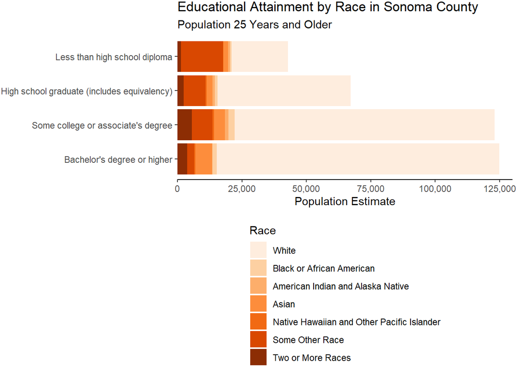

```r
## visualize data
ggplot(sonoma_edbyrace) +
  geom_bar(aes(x = factor(education, levels = unique(education)[c(1,4,2,3)]),
               y = estimate, fill = factor(race, levels = census_race_labels[1:7])),
           stat = 'identity') +
  scale_y_continuous(labels = comma, name = 'Population Estimate', expand = c(0,0),
                     limits = c(0, 130000)) +
  scale_fill_brewer(palette = 'Oranges', name = 'Race') +
  ggtitle('Educational Attainment by Race in Sonoma County',
          subtitle = 'Population 25 Years and Older') +
  coord_flip() +
  theme(legend.position = 'bottom', legend.direction = 'vertical',
        axis.title.y = element_blank(),
        plot.margin = margin(1, 10, 1, 1),
        panel.border = element_blank(), panel.grid = element_blank(),
        axis.line.x = element_line(color = 'black'))
```

Here we are presenting an equity analysis of educational attainment by race in Sonoma County, CA for residents 25 years and older, over the five-year period ending in 2018. It is clear that while the educational attainment of non-white residents is relatively evenly distributed over the four attainment categories, white residents overwhelmingly have at least some post-secondary education. 79.41% of the population is white, 69.27% of the population has at least some post-secondary education, and 58.84% of all Sonoma residents are both. What is impressive is that Sonoma appears to be a highly educated county. The next plot will dive a bit deeper into the proportions of the races within each educational attainment group.

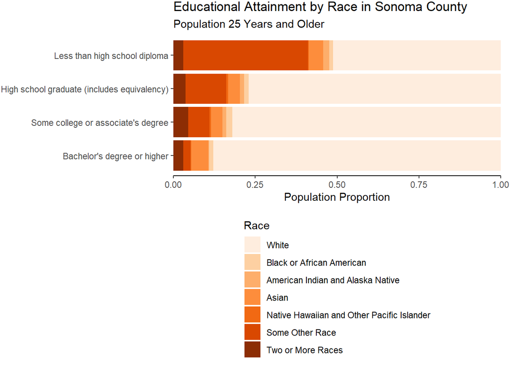

```r
ggplot(sonoma_edbyrace) +
  geom_bar(aes(x = factor(education, levels = unique(education)[c(1,4,2,3)]),
               y = estimate, fill = factor(race, levels = census_race_labels[1:7])),
           stat = 'identity', position = 'fill') +
  scale_y_continuous(name = 'Population Proportion', expand = c(0,0)) +
  scale_fill_brewer(palette = 'Oranges', name = 'Race') +
  ggtitle('Educational Attainment by Race in Sonoma County',
          subtitle = 'Population 25 Years and Older') +
  coord_flip() +
  theme(legend.position = 'bottom', legend.direction = 'vertical',
        axis.title.y = element_blank(),
        plot.margin = margin(1, 10, 1, 1),
        panel.border = element_blank(), panel.grid = element_blank(),
        axis.line.x = element_line(color = 'black'))
```

This chart shows the same information as the previous one, except the bars are now normalized by the total number in each educational attainment category. For example, the “Less than high school diploma” bar is showing us that of the people without high school diplomas or equivalents, 48.80% of them are non-white. On the other end of the spectrum, only 12.12% of people with bachelor’s degrees are non-white, and 43.04% of that small percentage are Asian.

One interesting thing to note is that the largest population without a high school diploma falls in the “Some Other Race” category. 9.92% of adults in Sonoma County checked this option, but these people represent over a third (38.15%) of Sonoma County adults without a high school diploma. The “Some Other Race” category has been growing in the past few decades as our population becomes more multiracial. While I was unable to find more information about race for this subset of the population in the ACS or in the PUMS data, other studies have shown that Latinx people and people who identify as MENA (Middle Eastern, North African, or Arab) often check the “Some Other Race” category because they do not feel properly represented by the existing ACS race labels.

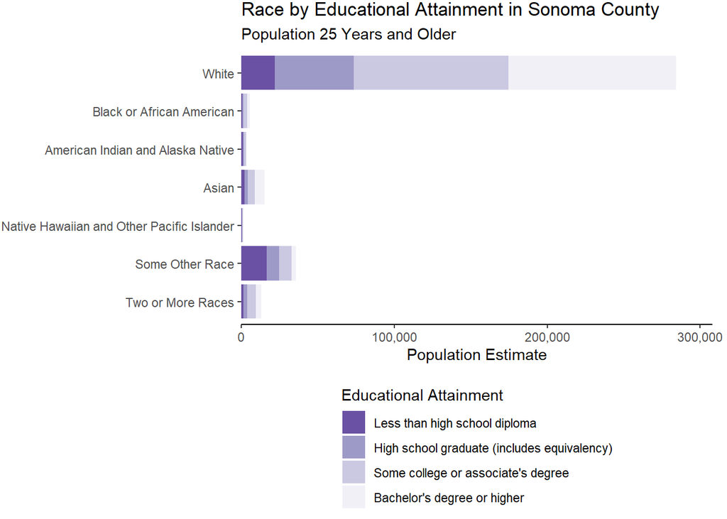

```r
ggplot(sonoma_edbyrace) +
  geom_bar(aes(x = factor(race, levels = census_race_labels[7:1]), y = estimate,
               fill = factor(education, levels = unique(education)[c(1,4,2,3)])),
           stat = 'identity') +
  scale_y_continuous(labels = comma, name = 'Population Estimate', expand = c(0, 0),
                     limits = c(0, 308000)) +
  scale_fill_brewer(palette = 'Purples', direction = 1, name = 'Educational Attainment',
                    guide = guide_legend(reverse = TRUE)) +
  ggtitle('Race by Educational Attainment in Sonoma County',
          subtitle = 'Population 25 Years and Older') +
  coord_flip() +
  theme(legend.position = 'bottom', legend.direction = 'vertical',
        axis.title.y = element_blank(),
        plot.margin = margin(1, 10, 1, 1),
        panel.border = element_blank(), panel.grid = element_blank(),
        axis.line.x = element_line(color = 'black'))
```

Now we can consider the relationshios between race and educational attainment through a different lens, looking at race by education instead of education by race. This plot, more than the first one, highlights the fact that Sonoma County is overwhelmingly (79.41%) white. The second largest racial group is Some Other Race (9.92%), followed by Asian (4.23%) and Two or More Races (3.63%). The remaining three racial groups make up just 2.82% of Sonoma residents. The next plot explores whether the educational attainment distribution looks similar across all races.

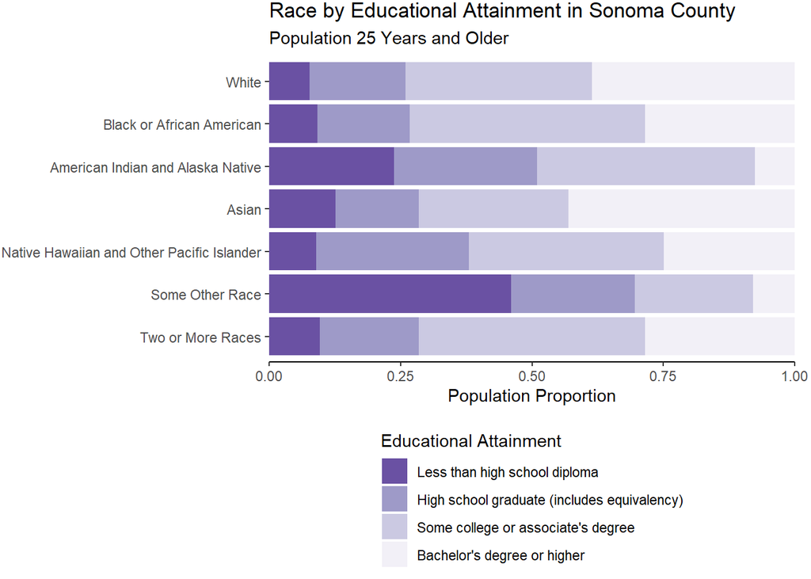

```r
ggplot(sonoma_edbyrace) +
  geom_bar(aes(x = factor(race, levels = census_race_labels[7:1]), y = estimate,
               fill = factor(education, levels = unique(education)[c(1,4,2,3)])),
           stat = 'identity', position = 'fill') +
  scale_y_continuous(name = 'Population Proportion', expand = c(0, 0)) +
  scale_fill_brewer(palette = 'Purples', direction = 1, name = 'Educational Attainment',
                    guide = guide_legend(reverse = TRUE)) +
  ggtitle('Race by Educational Attainment in Sonoma County',
          subtitle = 'Population 25 Years and Older') +
  coord_flip() +
  theme(legend.position = 'bottom', legend.direction = 'vertical',
        axis.title.y = element_blank(),
        plot.margin = margin(1, 10, 1, 1),
        panel.border = element_blank(), panel.grid = element_blank(),
        axis.line.x = element_line(color = 'black'))
```

Here we are looking at a normalized plot: of the members of each racial group, what percentage have reached a certain level of educational attainment? Again we can see that the Some Other Race group is significantly disadvantaged compared to other racial groups, and it is unfortunate that we do not have any further level of detail on how these people identify. However, there are a few new insights from this chart. First, the inequities experienced by American Indian and Alaska Native residents are visible for the first time. This is a very small subpopulation in Sonoma County, but within that subpopulation, less than half have had any sort of post-secondary education.

Another interesting population to examine is the Asian population. As mentioned in the previous plot, several Asian residents have achieved a bachelor’s degree or higher; here, we can see that the proportion of Asians in this category is actually larger than the proportion listed as White. However, Asians have the third highest percentage of residents with less than a high school diploma, and the smallest percentage in the “middle” two categories. This shows us that Asians experience the highest within-group educational attainment disparity. “Black or African American”, “Native Hawaiian or Other Pacific Islander”, and “Two or More Races” all look relatively similar and fall in between the extreme cases highlighted in this analysis.

```r
## define dictionary & geometries
pums_vars_2019 <- pums_variables %>% filter(year == 2019, survey == "acs1")
ca_pumas <- pumas("CA", cb = TRUE, class = 'sf', progress = FALSE)
bay_pumas <-
  suppressMessages(suppressWarnings(
    ca_pumas %>%
    st_centroid %>%
    .[bay_counties, ] %>%
    st_drop_geometry %>%
    left_join(ca_pumas %>% select(GEOID10)) %>%
    st_as_sf()
  ))

## get data for grade level & internet access

# pums_internet <- get_pums(variables = c('PUMA', 'ACCESS'), state = 'CA', year = 2019, survey = 'acs1')
# pums_students <- get_pums(variables = 'SCHG', state = 'CA', year = 2019, survey = 'acs1')
# save(pums_internet, pums_students,
#      file = 'C:/Users/cbowers/OneDrive/classes/CEE218X future of the bay area/cee218x/pums.Rdata')
load('C:/Users/cbowers/OneDrive/classes/CEE218X future of the bay area/cee218x/pums.Rdata')

pums_combined <- pums_internet %>%
  mutate(internet = ifelse(ACCESS %in% 1:2, TRUE, ifelse(ACCESS == 3, FALSE, NA))) %>%
  select(SERIALNO, SPORDER, PWGTP, PUMA, internet) %>%
  full_join(pums_students %>% select(SERIALNO, SPORDER, SCHG), by = c('SERIALNO', 'SPORDER')) %>%
  filter(!grepl('GQ', SERIALNO)) %>%
  filter(!grepl('bb', SCHG)) %>%
  mutate(SCHG = toNumber(SCHG), PUMA = toNumber(PUMA)) %>%
  filter(SCHG >= 2 & SCHG <= 14) %>%
  filter(PUMA %in% toNumber(bay_pumas$PUMACE10))
```

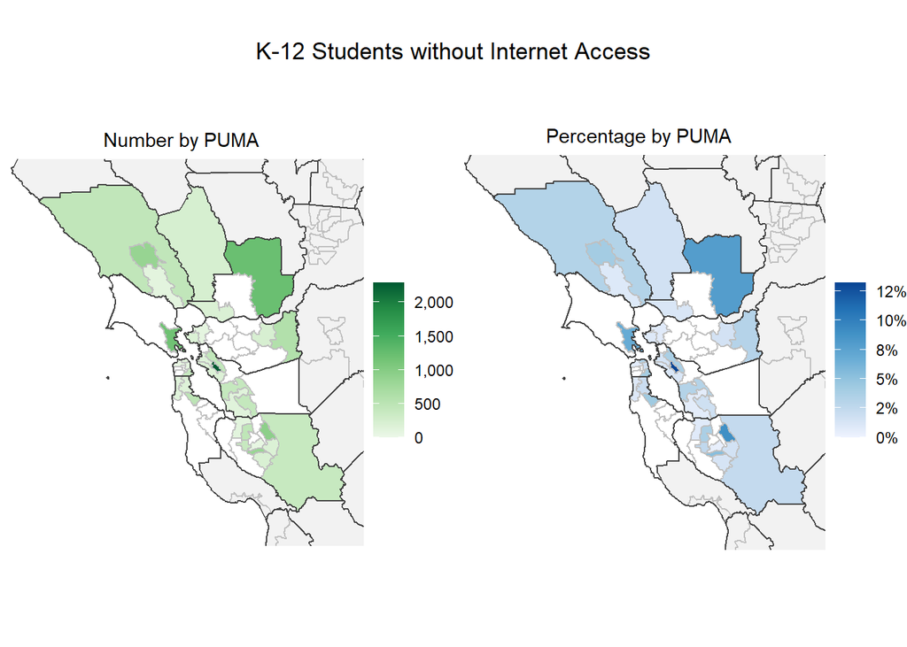

```r
## visualize internet access by PUMA
pums_plot <- pums_combined %>%
  group_by(PUMA) %>%
  summarize(pop = sum(PWGTP),
            pop_with_internet = sum(PWGTP*internet),
            internet_pct = pop_with_internet/pop,
            .groups = 'drop') %>%
  full_join(bay_pumas %>% mutate(PUMA = toNumber(PUMACE10)), ., by = 'PUMA')

g1 <- ggplot() +
  geom_sf(data = ca_pumas, fill = 'grey95', color = 'grey50') +
  geom_sf(data = pums_plot, aes(fill = pop-pop_with_internet)) +
  geom_sf(data = pums_plot %>% subset(pop == pop_with_internet), fill = 'white') +
  geom_sf(data = ca_pumas, fill = NA, color = 'grey75') +
  geom_sf(data = california, fill = NA, color = 'grey25') +
  ggtitle(label = waiver(), subtitle = 'Number by PUMA') +
  scale_fill_distiller(name = element_blank(), palette = 'Greens',
                       label = comma, direction = 1) +
  coord_sf(xlim = c(-123.7, -121.2), ylim = c(36.8, 38.9)) +
  theme_void() +
  theme(plot.subtitle = element_text(margin = margin(0,0,5,0), hjust = 0.5))
g2 <- ggplot() +
  geom_sf(data = ca_pumas, fill = 'grey95', color = 'grey50') +
  geom_sf(data = pums_plot, aes(fill = 1-internet_pct)) +
  geom_sf(data = pums_plot %>% subset(internet_pct == 1), fill = 'white') +
  geom_sf(data = ca_pumas, fill = NA, color = 'grey75') +
  geom_sf(data = california, fill = NA, color = 'grey25') +
  ggtitle(label = waiver(), subtitle = 'Percentage by PUMA') +
  scale_fill_distiller(name = element_blank(), palette = 'Blues',
                       label = percent_format(accuracy = 1), direction = 1) +
  coord_sf(xlim = c(-123.7, -121.2), ylim = c(36.8, 38.9)) +
  theme_void() +
  theme(plot.subtitle = element_text(margin = margin(0,0,5,0), hjust = 0.5))
grid.arrange(g1, g2, ncol = 2,
             top = textGrob('K-12 Students without Internet Access', vjust = 2.5, gp = gpar(cex = 1.1)))
```

Here we are using Public Use Microdata Surveys (PUMS) to look at the number and percentage of K-12 students in the Bay Area who do not have internet access. This was important pre-COVID as more and more of our educational resources move online, but it has become even more critical for distanced learning.

As shown in the plots above, there are wide swaths of the Bay where 100% of students have internet access. It may be hard to believe that; no Bay Area county provides free wifi to all residents, and without that sort of intervention, when is there 100% coverage of anything? It is useful to keep in mind that PUMS data points only represent a portion of residents within any geographic area, and then each of these points is “weighted” to represent a certain number of similar people. It is quite possible that everyone sampled in the white areas above had internet access, but that there exists a very small subpopulation who was not accounted for.

The vast majority of Public Use Microdata Areas (PUMAs) have 5% or lower of K-12 students lacking internet access. However, there are a few areas that emerge as outliers, particularly in Alameda County. The interactive plot below will let us explore that area in more detail.

```r
## make it interactive
res_pal <- colorNumeric(palette = "Blues", domain = 1-pums_plot$internet_pct)
res_pal_reverse <- colorNumeric(palette = "Blues", domain = 1-pums_plot$internet_pct, reverse = TRUE)

puma_label <- function(x) lapply(seq(nrow(x)), function(i) paste0('<p>', 'PUMA:', x$PUMA[i], '</p><p>',
                                    x$pop[i] - x$pop_with_internet[i], ' students', '</p>'))
leaflet() %>%
  addTiles() %>%
  addPolygons(data = pums_plot %>% subset(internet_pct < 1) %>% st_transform(crs_leaflet),
              color = 'gray', weight = 1,
              fillColor = ~res_pal(1-internet_pct),
              fillOpacity = 0.75,
              label = lapply(puma_label(pums_plot %>% subset(internet_pct < 1)), htmltools::HTML)) %>%
  addPolygons(data = pums_plot %>% subset(internet_pct == 1) %>% st_transform(crs_leaflet),
              color = 'gray', weight = 1,
              fillColor = 'white',
              fillOpacity = 0.75,
              label = lapply(puma_label(pums_plot %>% subset(internet_pct == 1)), htmltools::HTML)) %>%
  addLegend("topright",
            pal = res_pal_reverse,
            values = 1 - pums_plot$internet_pct, opacity = 0.9,
            labFormat = labelFormat(transform = function(x) sort(x, decreasing = TRUE)))
```

[interactive chart not shown]

If we zoom in to Alameda County, we see a PUMA #104 just south of Oakland with 2,292 students (12% of the K-12 population) who do not have internet access. It is surrounded by areas with much higher internet access, so it is not clear what makes this particular PUMA fall so far behind its neighbors. More analysis is necessary to understand the demographics and socioeconomic drivers in this area.

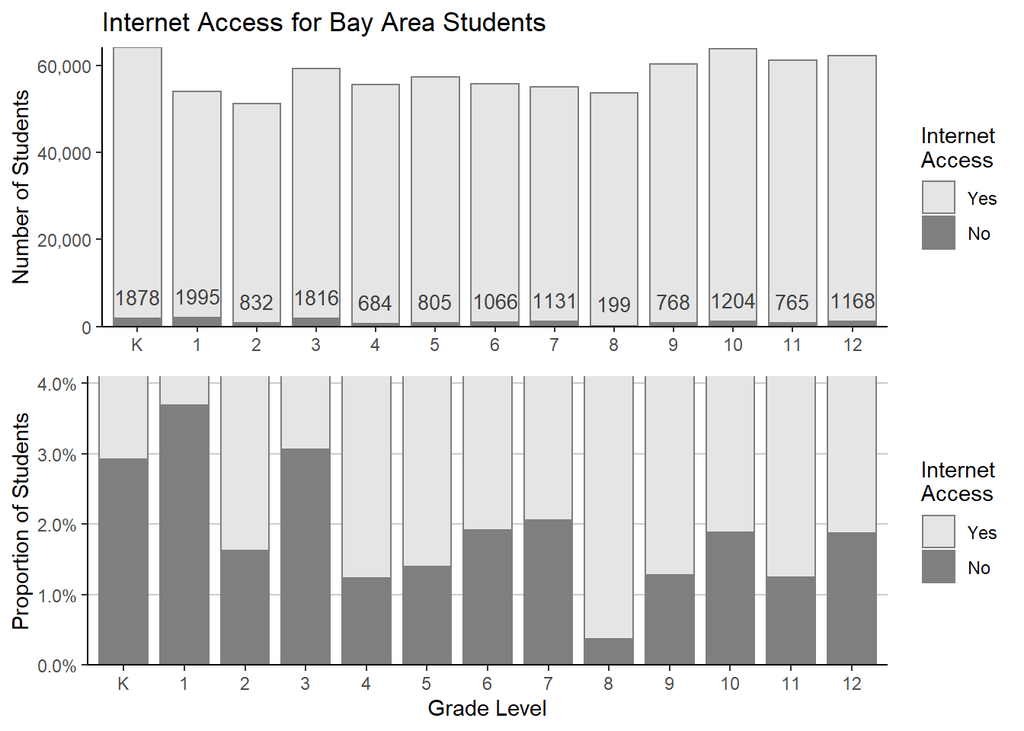

```r
## visualize internet access by grade
pums_bygrade <- pums_combined %>%
  mutate(grade = ifelse(SCHG <= 7, 'Elementary', ifelse(SCHG <= 10, 'Middle', 'High'))) %>%
  group_by(PUMA, internet, grade) %>%
  summarize(estimate = sum(PWGTP), .groups = 'drop') %>%
  pivot_wider(id_cols = c(PUMA, internet), names_from = grade, values_from = estimate)
g.number <- ggplot(pums_combined %>%
         group_by(internet, SCHG) %>%
         summarize(estimate = sum(PWGTP), .groups = 'drop') %>%
         mutate(grade = factor(ifelse(SCHG == 2, 'K', SCHG-2), levels = c('K', 1:12)))) +
  geom_bar(aes(x = grade, y = estimate, fill = factor(-internet)),
           stat = 'identity', color = 'grey50', width = 0.8) +
  geom_text(data = pums_combined %>% subset(!internet) %>%
              group_by(grade = factor(ifelse(SCHG == 2, 'K', SCHG-2), levels = c('K', 1:12))) %>%
              summarize(estimate = sum(PWGTP), .groups = 'drop'),
            aes(x = grade, y = estimate + 5e3, label = estimate), size = 3.5, color = 'grey25') +
  scale_fill_manual(name = 'Internet \nAccess', labels = c('Yes', 'No'), values = c('grey90', 'grey50')) +
  scale_y_continuous(expand = c(0,0), labels = comma) +
  ggtitle('Internet Access for Bay Area Students') +
  labs(y = 'Number of Students') +
  theme_classic() + theme(axis.title.x = element_blank())
g.percent <- ggplot(pums_combined %>%
         group_by(internet, SCHG) %>%
         summarize(estimate = sum(PWGTP), .groups = 'drop') %>%
         mutate(grade = factor(ifelse(SCHG == 2, 'K', SCHG-2), levels = c('K', 1:12)))) +
  geom_bar(aes(x = grade, y = estimate, fill = factor(-internet)),
           stat = 'identity', position = 'fill', color = 'grey50', width = 0.8) +
  scale_fill_manual(name = 'Internet \nAccess', labels = c('Yes', 'No'), values = c('grey90', 'grey50')) +
  scale_y_continuous(expand = c(0,0), labels = percent) +
  # ggtitle('Internet Access for Bay Area Students') +
  labs(x = 'Grade Level', y = 'Proportion of Students') +
  coord_cartesian(ylim = c(0, 0.041)) +
  theme(panel.border = element_blank(),
        axis.line = element_line(color = 'black'),
        panel.grid.major.y = element_line(color = 'grey80'),
        panel.grid.minor = element_blank())
grid.arrange(g.number, g.percent, nrow = 2)
```

Another way to look at internet access for K-12 students is to look at the breakdown by grade level rather than geography. The top plot looks at the number of students in each grade level (in 2019) who do not have internet access. The bottom plot is the proportion of students in each grade level who do not have internet access, truncated at 4% to view the differences between grade levels a bit better.

Averaged across the nine Bay Area counties, over 95% of students at every grade level have internet access, and the general trend is that internet access increases with increasing age/grade level. This is actually a bit worrisome, because numbers this high lead administrators and teachers to believe that everyone has equitable access, and it is a very real possibility that the small subset of children without internet access may not get the attention or resources they need and fall behind academically.

```r
## measure people who remained + inflow (ACS B07009)
mobility_current_2019 <-
  getCensus(name = "acs/acs1", vintage = 2019, vars = c("group(B07009)"),
            regionin = "state:06", region = "county:097") %>%
  select(-c(GEO_ID, state, NAME)) %>%
  select(-ends_with('EA'), -ends_with('M'), -ends_with('MA')) %>%
  pivot_longer(ends_with("E"), names_to = "variable", values_to = "estimate") %>%
  left_join(acs_vars_2019_1yr %>% select(name, label), by = c("variable" = "name")) %>%
  select(-variable) %>%
  separate(label, into = c(NA, NA, 'mobility', 'education'), sep = "!!", fill = 'right') %>%
  mutate(mobility = gsub(":", "", mobility), education = gsub(":", "", education)) %>%
  filter(!is.na(mobility) & !is.na(education)) %>%
  mutate(mobility = ifelse(mobility %in% c("Same house 1 year ago", "Moved within same county"),
                           "here since last year", "inflow")) %>%
  group_by(mobility, education) %>%
  summarize(estimate = sum(estimate), .groups = 'drop')

## measure people who remained + outflow (ACS B07409)
mobility_lastyear_2019 <-
  getCensus(name = "acs/acs1", vintage = 2019, vars = c("group(B07409)"),
            regionin = "state:06", region = "county:097") %>%
  select(-c(GEO_ID, state, NAME)) %>%
  select(-ends_with('EA'), -ends_with('M'), -ends_with('MA')) %>%
  pivot_longer(ends_with("E"), names_to = "variable", values_to = "estimate") %>%
  left_join(acs_vars_2019_1yr %>% select(name, label), by = c("variable" = "name")) %>%
  select(-variable) %>%
  separate(label, into = c(NA, NA, 'mobility', 'education'), sep = "!!", fill = 'right') %>%
  mutate(mobility = gsub(":", "", mobility), education = gsub(":", "", education)) %>%
  filter(!is.na(mobility) & !is.na(education)) %>%
  mutate(mobility = ifelse(mobility %in% c("Same house", "Moved within same county"),
                           "here since last year", "outflow")) %>%
  group_by(mobility, education) %>%
  summarize(estimate = sum(estimate), .groups = 'drop')

## check datasets
sum(mobility_current_2019$estimate[mobility_current_2019$mobility == 'here since last year']) ==
  sum(mobility_lastyear_2019$estimate[mobility_lastyear_2019$mobility == 'here since last year'])
```

```
## [1] TRUE
```

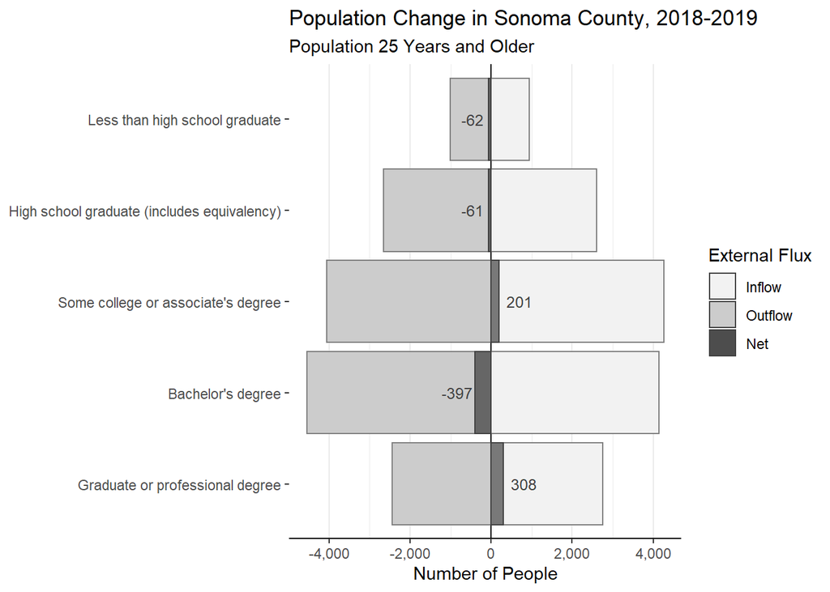

```r
## compare to last year's population
mobility_current_2018 <-
  getCensus(name = "acs/acs1", vintage = 2018, vars = c("group(B07009)"),
            regionin = "state:06", region = "county:097") %>%
  select(-c(GEO_ID, state, NAME)) %>%
  select(-ends_with('EA'), -ends_with('M'), -ends_with('MA')) %>%
  pivot_longer(ends_with("E"), names_to = "variable", values_to = "estimate") %>%
  left_join(acs_vars_2019_1yr %>% select(name, label), by = c("variable" = "name")) %>%
  select(-variable) %>%
  separate(label, into = c(NA, NA, 'mobility', 'education'), sep = "!!", fill = 'right') %>%
  mutate(mobility = gsub(":", "", mobility), education = gsub(":", "", education)) %>%
  filter(!is.na(mobility) & !is.na(education)) %>%
  mutate(mobility = "here last year") %>%
  group_by(mobility, education) %>%
  summarize(estimate = sum(estimate), .groups = 'drop')

## combine inflow/outflow data into one "flows" dataframe
sonoma_flows_2019 <-
  rbind(mobility_current_2018,
        mobility_lastyear_2019 %>% filter(mobility == "outflow"),
        mobility_current_2019 %>% filter(mobility == "inflow")) %>%
  as.data.frame %>%
  rbind(mobility_current_2019 %>%
          group_by(education) %>%
          summarize(estimate = sum(estimate), .groups = 'drop') %>%
          mutate(mobility = 'here this year') %>%
          select(mobility, education, estimate)) %>%
  pivot_wider(names_from = mobility, values_from = estimate) %>%
  mutate(`external net` = inflow - outflow,
         `internal net` = `here this year` - `here last year` - `external net`)
#external net = inflow - outflow
#internal net = births, deaths, etc.

## visualize results
ggplot(sonoma_flows_2019 %>%
         pivot_longer(cols = c('outflow', 'inflow'), names_to = 'change', values_to = 'estimate') %>%
         mutate(estimate = ifelse(change == 'outflow', -estimate, estimate),
                `external net` = ifelse(change == 'outflow', `external net`, 0))) +
  geom_hline(yintercept = 0) +
  geom_bar(aes(x = factor(education, levels = unique(education)[c(2,1,5,3,4)]),
               y = estimate, group = change, fill = change), stat = 'identity', color = 'grey50') +
  geom_bar(aes(x = factor(education, levels = unique(education)[c(2,1,5,3,4)]),
               y = `external net`, fill = 'net'), stat = 'identity', color = 'grey25', alpha = 0.5) +
  scale_fill_manual(values = c('grey95', 'grey80', 'black'),
                    breaks = c('inflow', 'outflow', 'net'),
                    labels = c('Inflow', 'Outflow', 'Net')) +
  scale_y_continuous(breaks = seq(-4e3, 4e3, 2e3), labels = comma) +
  guides(fill = guide_legend(override.aes = list(alpha = c(1, 1, 0.45)))) +
  ggtitle('Population Change in Sonoma County, 2018-2019',
          subtitle = 'Population 25 Years and Older') +
  labs(y = 'Number of People', fill = 'External Flux') +
  geom_text(data = sonoma_flows_2019,
            aes(x = factor(education, levels = unique(education)[c(2,1,5,3,4)]),
                y = `external net` + 450*sign(`external net`),
                label = format(`external net`, big.mark = ',')),
            size = 3.25, color = 'grey25') +
  theme(panel.border = element_blank(),
        axis.line.x = element_line(color = 'black'),
        panel.grid.major.y = element_blank(),
        axis.title.y = element_blank()) +
  coord_flip()
```

This plot shows the external population change in Sonoma County from 2018-2019, broken out by level of educational attainment. Inflow refers to people who have moved to the county in the last year, outflow refers to people who have left the county in the past year, and net refers to the net change in the number of people in a given educational attainment class. Based on how the data source, we have one additional category of attainment that was not considered in our first analysis; instead of “Bachelor’s degree or higher”, we have the dual categories of “Bachelor’s degree” and “Graduate or professional degree.”

The shape of this chart is almost bell-like; we have little mobility in the high school and less than high school categories, we have the most movement among people with some college, associate’s, or bachelor’s, and we have comparatively less among people with advanced degrees. This tracks with our intuition; higher levels of educational attainment are associated with higher economic mobility, which translates to physical mobility.

“Less than high school graduate” “High school graduate/high school equivalency”, and “Bachelor’s degree” also saw net negative external flux, while “Some college or associate’s degree” and “Graduate or professional degree” saw net positive external flux. The “Bachelor’s degree” category disrupts the trend of increasing net inflow with increasing educational attainment; it would be interesting to expand the analysis to other years and see if this trend holds true over time or is an anomaly for 2018-2019.

```r
## get total population by education level (ACS B15002)
sonoma_ed_2019 <-
  getCensus(name = "acs/acs1", vintage = 2019, vars = 'group(B15002)',
            regionin = "state:06", region = "county:097") %>%
  select(-c(GEO_ID, state, county, NAME)) %>%
  select(-ends_with('EA'), -ends_with('M'), -ends_with('MA')) %>%
  pivot_longer(cols = ends_with('E'), names_to = 'variable', values_to = 'estimate') %>%
  left_join(acs_vars_2019_1yr %>% select(name, label), by = c('variable' = 'name')) %>%
  select(-variable) %>%
  separate(label, into = c(NA, NA, "sex", "education_year"), sep = "!!", fill = 'right') %>%
  filter(!is.na(education_year)) %>%
  mutate(education =
    ifelse(education_year %in% c("No schooling completed", "Nursery to 4th grade", "5th and 6th grade",
                                 "7th and 8th grade", "9th grade", "10th grade", "11th grade",
                                 "12th grade, no diploma"),
           "Less than high school graduate",
    ifelse(education_year %in% c("Some college, less than 1 year", "Some college, 1 or more years, no degree",
                                 "Associate's degree"),
           "Some college or associate's degree",
    ifelse(education_year %in% c("Master's degree", "Professional school degree", "Doctorate degree"),
           "Graduate or professional degree", education_year)))) %>%
  group_by(education) %>%
  summarize(estimate = sum(estimate), .groups = 'drop')

## compare to make sure we have the right population counts by education level
mobility_current_2019 %>%
  group_by(education) %>%
  summarize(estimate = sum(estimate), .groups = 'drop') %>%
  mutate(check = (estimate == sonoma_ed_2019$estimate)) %>%
  select(-estimate)
```

```
## # A tibble: 5 x 2
##   education                                   check
##   <chr>                                       <lgl>
## 1 Bachelor's degree                           TRUE
## 2 Graduate or professional degree             TRUE
## 3 High school graduate (includes equivalency) TRUE
## 4 Less than high school graduate              TRUE
## 5 Some college or associate's degree          TRUE
```

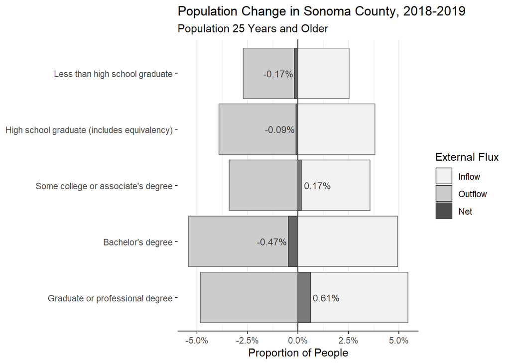

```r
## visualize results
sonoma_flows_2019 <- sonoma_flows_2019 %>%
  full_join(sonoma_ed_2019 %>% rename(`total pop` = estimate), by = 'education') %>%
  mutate(inflow_proportion = inflow/`total pop`,
         outflow_proportion = outflow/`total pop`,
         net_proportion = `external net`/`total pop`)
ggplot(sonoma_flows_2019 %>%
         pivot_longer(cols = c('outflow_proportion', 'inflow_proportion'),
                      names_to = 'change', values_to = 'prop') %>%
         mutate(prop = ifelse(change == 'outflow_proportion', -prop, prop))) +
  geom_hline(yintercept = 0) +
  geom_bar(aes(x = factor(education, levels = unique(education)[c(2,1,5,3,4)]),
               y = prop, group = change, fill = change), stat = 'identity', color = 'grey50') +
  geom_bar(data = sonoma_flows_2019,
           aes(x = factor(education, levels = unique(education)[c(2,1,5,3,4)]),
               y = net_proportion, fill = 'net'), stat = 'identity', color = 'grey25', alpha = 0.5) +
  scale_fill_manual(values = c('grey95', 'grey80', 'black'),
                    breaks = c('inflow_proportion', 'outflow_proportion', 'net'),
                    labels = c('Inflow', 'Outflow', 'Net')) +
  scale_y_continuous(labels = percent, breaks = seq(-7.5, 7.5, 2.5)/100) +
  guides(fill = guide_legend(override.aes = list(alpha = c(1, 1, 0.45)))) +
  ggtitle('Population Change in Sonoma County, 2018-2019',
          subtitle = 'Population 25 Years and Older') +
  labs(y = 'Proportion of People', fill = 'External Flux') +
  geom_text(data = sonoma_flows_2019,
            aes(x = factor(education, levels = unique(education)[c(2,1,5,3,4)]),
                y = net_proportion + 0.008*sign(net_proportion),
                label = paste0(round(net_proportion*100,2), '%')),
            size = 3.25, color = 'grey25') +
  theme(panel.border = element_blank(),
        axis.line.x = element_line(color = 'black'),
        panel.grid.major.y = element_blank(),
        axis.title.y = element_blank()) +
  coord_flip()
```

To further investigate our hypothesis that higher educational attainment = more physical ability, we normalized the plot to represent the proportion of people in each educational attainment group coming to or leaving Sonoma County. Here the trend is even clearer. There are not that many people with graduate or professional degrees, but they have the highest net flux; About 5% of people with graduate or professional degrees “turned over” between 2018 and 2019, resulting in a net inflow of 0.61% of this sub-population. Interestingly, people with bachelor’s degrees had a very similar turnover rate, but it resulted in a net outflow.

The normalized plot shows more clearly the lack of “educational mobility” for people with lower attainment, especially those without high school degrees or equivalents. This population saw a turnover of almost half that of the population with bachelor’s and graduate/professional degrees. There are multiple possible explanations for this, but some possibilities include: lack of affordable housing options elsewhere/general housing shortages, lack of employment opportunities elsewhere, or close-knit family or community groups.